# Fly ATAC Atlas

元URL: http://atlas.gs.washington.edu/fly-atac/docs/

- このノートブックでは、Drosophila melanogasterの胚の scATAC-seqデータを使用して作業するための分析のいくつかを学習します。
  - 元論文: Cusanovich et. al ([bioRxiv 2017](https://www.biorxiv.org/content/early/2017/07/20/166066))
- チュートリアルは以下のセクションに分かれています。
  - 類似の chromatin accessibility profiles を持つ細胞の系統群 (clade) を同定するための **latent semantic indexing (‘LSI’)**
  - t-SNEを用いた詳細な構造の同定
  - クラスター間で異なるchromatin accessible 部位の同定
  - **“pseudotemporal ordering”** を用いた発生軌跡に沿った細胞の整列

```r
# Load packages
suppressPackageStartupMessages({
        library(Matrix)
        library(proxy)
        library(gplots)
        library(Rtsne)
        library(densityClust)
        library(irlba)
    })
```

## Use case 1: ID clades with ‘LSI’

- データをloci x cell の sparse binary matrixとして保存するのが便利です。
- 以下では、個々の細胞レベルで2kb window でマップされているかどうかを全ゲノム的にスコア化した解析をご紹介します。
- FASTQファイルは、Gene Expression OmnibusのGSE101581で入手できます。
- これらのファイルを操作するためのツールを[github](https://github.com/shendurelab/fly-atac/)で公開しています。
- また、私たちの[コンパニオンサイト](http://shiny.furlonglab.embl.de/scATACseqBrowser/)には、データを操作するための多くのリソースがあります。

```r
# Download data
download.file(
        "http://krishna.gs.washington.edu/content/members/cusanovich/fly_embryogenesis/updated_data/vignette/6to8.2kbmatrix.sparse.binary.rds",
        destfile = "6to8.2kbmatrix.sparse.binary.rds"
)
```

```r
# load data
flies_6to8 = readRDS("6to8.2kbmatrix.sparse.binary.rds")
```

- ENCODEで定義されたブラックリスト領域と重なる2kbウィンドウをフィルタリングした結果、ショウジョウバエゲノムから 83,290個の 2kbウィンドウが得られました。
- 6-8時間の時点で7,880個の細胞が得られました。

```r
dim(flies_6to8)
flies_6to8[1:2,1:2]
```

1. 83290

2. 7880

```
2 x 2 sparse Matrix of class "dgCMatrix"
                AGCGATAGAACGAATTCGAGAACCGGAGCCTATCCT
chr2L_0_2000                                       .
chr2L_2000_4000                                    .
                AGCGATAGAACGAATTCGAGTCATAGCCGTACTGAC
chr2L_0_2000                                       .
chr2L_2000_4000                                    .
```

- 個々のwindowにマップされる頻度と、個々の細胞で観察されるwindowのバラエティについて、いくつかの情報を集めてみましょう。
- あるサイトは最大で6,322個（80％）の細胞で観察されているが、各サイトごとのリードがマップされた細胞数の中央値は330個で、対数スケールでは大まかに正規分布している（長いtailを持つ）ことがわかる。

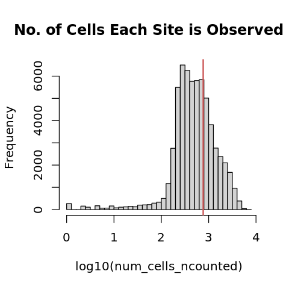

```r
num_cells_ncounted = rowSums(flies_6to8)
options(repr.plot.width=4, repr.plot.height=4)
hist(log10(num_cells_ncounted),main="No. of Cells Each Site is Observed In", breaks=50)
abline(v=log10(num_cells_ncounted[order(num_cells_ncounted,decreasing=T)[20000]]),lwd=2,col="indianred")
```

- ここでは、最もよく使われているサイト(ここでは上位20,000サイト)だけを保持してみましょう。
- 各セルがカバーしている上位20,000サイトの数の分布を見ると、各セルがカバーしているウィンドウの中央値は3,751個で、分布は粗い対数正規分布（下側に長いtailを持つ）であることがわかります。

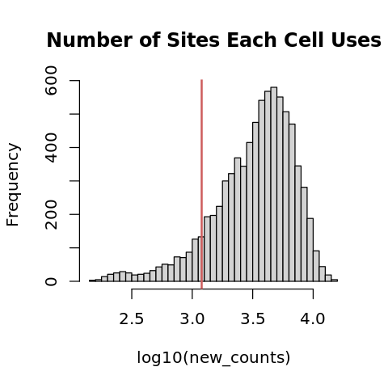

```r
ncounts = flies_6to8[which(num_cells_ncounted >= num_cells_ncounted[order(num_cells_ncounted,decreasing=T)[20000]]),]
new_counts = colSums(ncounts)
hist(log10(new_counts),main="Number of Sites Each Cell Uses", breaks=50)
abline(v=log10(quantile(new_counts,probs=0.1)),lwd=2,col="indianred")
```

```r
ncounts = ncounts[,new_counts >= quantile(new_counts,probs=0.1)]
ncounts = ncounts[rowSums(ncounts) > 0,]
```

その後、TF-IDFを用いてデータを変換し、truncated SVDを用いて次元削減を行う（これらはLSIの2つの主要なステップである）。

```r
nfreqs = t(t(ncounts) / Matrix::colSums(ncounts))
idf = as(log(1 + ncol(ncounts) / Matrix::rowSums(ncounts)), "sparseVector")
tf_idf_counts = as(Diagonal(x=as.vector(idf)), "sparseMatrix") %*% nfreqs
```

ここでは、第2～第6成分のみを保持し（第一成分はread depthと相関が高い）、LSIの値の分布を+/-1.5で切り捨てている。

```r
set.seed(0) #For reproducibility

SVD = irlba(tf_idf_counts, 6, 6)
sk_diag = matrix(0, nrow=6, ncol=6)
diag(sk_diag) = SVD$d
sk_diag[1,1] = 0

LSI_out = t(t(sk_diag %*% t(SVD$v)) %*% t(SVD$u))
LSI_out = t(scale(t(LSI_out)))
LSI_out[LSI_out > 1.5] = 1.5
LSI_out[LSI_out < -1.5] = -1.5
```

Next, we generate some info about the dendrograms that will be used for plotting the heatmap.

```r
hclust_cells = hclust(proxy::dist(t(sk_diag %*% t(SVD$v)), method="cosine"), method="ward.D2")
hclust_genes = hclust(proxy::dist(t(sk_diag %*% t(SVD$u)), method="cosine"), method="ward.D2")

color_pal = c("#1F78B4","#FFD700","#60CC52","#E31A1C")
hmcols = colorpanel(100, "steelblue", "white", "tomato")
cells_tree_cut = cutree(hclust_cells, 4)
lsi_cells = cbind(colnames(ncounts),cells_tree_cut)
```

Finally, we can generate a bi-clustered heatmap showing how cells and sites are related.

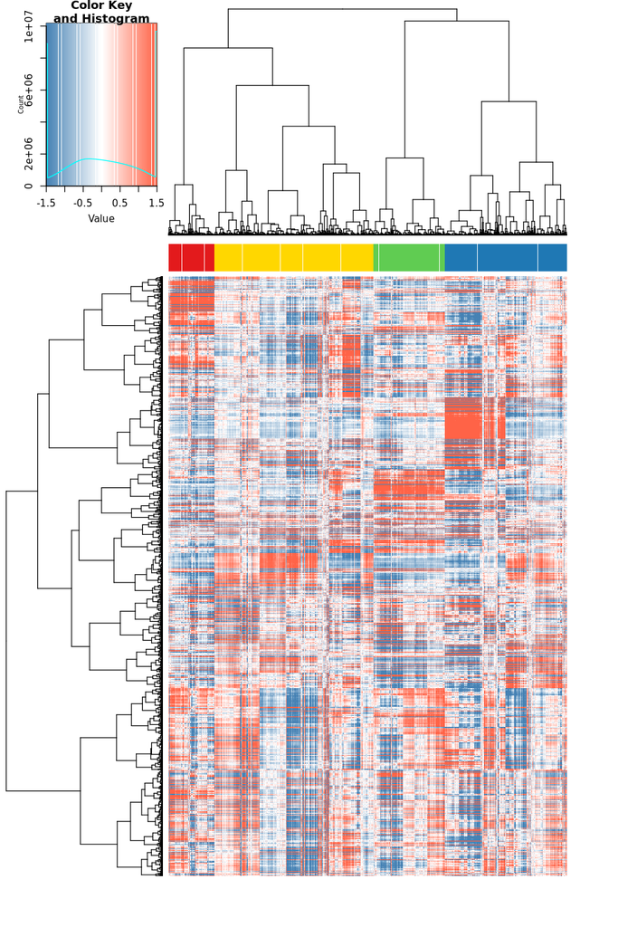

```r
options(repr.plot.width=8, repr.plot.height=12)
heatmap.2(LSI_out,
          col=hmcols,
          ColSideColors=color_pal[as.factor(cells_tree_cut)],
          #RowSideColors=color_pal[as.factor(genes_tree_cut)],
          Rowv = as.dendrogram(hclust_genes), Colv = as.dendrogram(hclust_cells),
          labRow=FALSE, labCol=FALSE, trace="none",  scale="none",
          useRaster=TRUE)
```

```r
# 変数の削除
rm(flies_6to8)
rm(ncounts)
rm(nfreqs)
rm(tf_idf_counts)
rm(SVD)
rm(LSI_out)
```

## Use case 2: Re-cluster cells with t-SNE

- 胚発生期における生殖層の発達と一致する大きな細胞群を同定した後、各クラスターに割り当てられた細胞を「in silico ソーティング」し、各クラスターにおけるクロマチンアクセシビリティのピークを同定することができた。(Pseudo bulk)
- 次に、個々の細胞タイプとより一致している可能性のあるより小さな細胞のクラスターを頑健に同定し、異なる細胞状態を支配する個々の制御因子について知ることを目指した。
- そのために、3つのタイムポイントにおいて各cladeで同定されたピークsummit のマスターリストを生成し、細胞ごとのサイトのマトリックスを作成した（前回の使用例と同様）。

```r
# Download and load data
download.file(
    "http://krishna.gs.washington.edu/content/members/cusanovich/fly_embryogenesis/updated_data/vignette/6to8.summitmatrix.sparse.binary.rds",
    destfile = "6to8.summitmatrix.sparse.binary.rds")
fly_summits_6to8 = readRDS("6to8.summitmatrix.sparse.binary.rds")
dim(fly_summits_6to8)
fly_summits_6to8[1:2,1:2]
```

1. 53133

2. 7880

```
2 x 2 sparse Matrix of class "dgCMatrix"
                AGCGATAGAACGAATTCGAGAACCGGAGCCTATCCT
chr2L_5543_5980                                    .
chr2L_6666_6881                                    .
                AGCGATAGAACGAATTCGAGTCATAGCCGTACTGAC
chr2L_5543_5980                                    .
chr2L_6666_6881                                    .
```

- 分析は上の**LSI**の例と同様に開始する。
- 最初に、少ない細胞でしか観測されないサイトをフィルタリングし（この場合、少なくとも5%の細胞で見られるサイトのみを保持する）、次に比較的低いカバレッジを持つ細胞をフィルタリングする（再び、最も低い10%の細胞をフィルタリングする）。

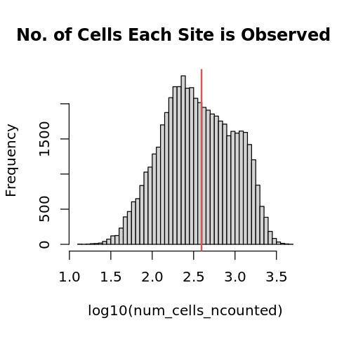

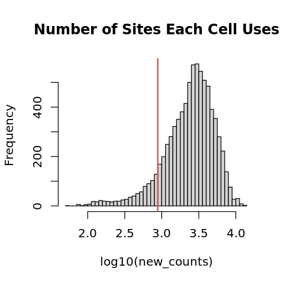

```r
num_cells_ncounted = rowSums(fly_summits_6to8)
ncounts = fly_summits_6to8[num_cells_ncounted >= dim(fly_summits_6to8)[2]*0.05,]
new_counts = colSums(ncounts)
ncounts = ncounts[,new_counts >= quantile(new_counts,probs=0.1)]
ncounts = ncounts[rowSums(ncounts) > 0,]

options(repr.plot.width=4, repr.plot.height=4)
hist(log10(num_cells_ncounted),main="No. of Cells Each Site is Observed In",breaks=50)
abline(v=log10(min(num_cells_ncounted[num_cells_ncounted >= dim(fly_summits_6to8)[2]*0.05])),lwd=2,col="indianred")
hist(log10(new_counts),main="Number of Sites Each Cell Uses",breaks=50)
abline(v=log10(quantile(new_counts,probs=0.1)),lwd=2,col="indianred")
```

```r
sexsites = c(grep("chrY",rownames(ncounts)),grep("chrX",rownames(ncounts)))
ncounts.nosex = ncounts[-sexsites,]

nfreqs = t(t(ncounts.nosex) / Matrix::colSums(ncounts.nosex))
idf = as(log(1 + ncol(ncounts.nosex) / Matrix::rowSums(ncounts.nosex)), "sparseVector")
tf_idf_counts = as(Diagonal(x=as.vector(idf)), "sparseMatrix") %*% nfreqs

set.seed(0)
SVDtsne = irlba(tf_idf_counts, 50, 50)
d_diagtsne = matrix(0, nrow=50, ncol=50)
diag(d_diagtsne) = SVDtsne$d
SVDtsne_vd = t(d_diagtsne %*% t(SVDtsne$v))


dim(ncounts.nosex)
ncounts.nosex[1:2,1:2]
tf_idf_counts[1:2,1:2]
```

1. 19956

2. 7092

```
2 x 2 sparse Matrix of class "dgCMatrix"
                AGCGATAGAACGAATTCGAGAACCGGAGCCTATCCT
chr2L_5543_5980                                    .
chr2L_7488_8077                                    .
                AGCGATAGAACGAATTCGAGTCATAGCCGTACTGAC
chr2L_5543_5980                                    .
chr2L_7488_8077                                    .
```

```
2 x 2 sparse Matrix of class "dgCMatrix"
                AGCGATAGAACGAATTCGAGAACCGGAGCCTATCCT
chr2L_5543_5980                                    .
chr2L_7488_8077                                    .
                AGCGATAGAACGAATTCGAGTCATAGCCGTACTGAC
chr2L_5543_5980                                    .
chr2L_7488_8077                                    .
```

次に、t-SNEを使用してデータを可視化します。この低次元表現データを直接Rtsneパッケージに送ります。

```r
set.seed(0)
tsnetfidf = Rtsne(SVDtsne_vd, pca=F)
```

To identify clusters of cells, we use the density peak algorithm.

```r
tsnedist = dist(tsnetfidf$Y)
set.seed(0)
dclust = densityClust(tsnedist, gaussian=T)
dclust = findClusters(dclust, rho = 50, delta = 2.5)
```

```
Distance cutoff calculated to 3.423262
```

- density peak アルゴリズムでは、2つのパラメータ、`delta` と `rho` を設定する必要があります。
- このアルゴリズムは、各データ点について、設定された距離内にある他の点の局所密度を計算し、またより高い局所密度を持つ次の点までの最小距離を計算します。
- これら2つの値に基づいて、局所密度とより高い密度を持つ別の点までの距離の両方で外れ値である点のセットを選択することができ、それがクラスター (ピーク)となります。
- 以下に、我々のデータセットにおけるこれら2つの値の分布と、カットオフを引くことにした場所を示します。
- このアルゴリズムについての詳細: http://science.sciencemag.org/content/344/6191/1492

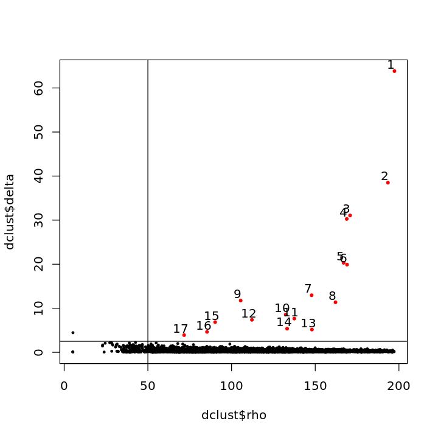

```r
options(repr.plot.width=6, repr.plot.height=6)

plot(dclust$rho, dclust$delta, pch=20, cex=0.6)

points(dclust$rho[dclust$peaks],
       dclust$delta[dclust$peaks],
       col = "red",
       pch = 20,
       cex = 0.8)
text(dclust$rho[dclust$peaks] -2,
     dclust$delta[dclust$peaks] +1.5,
     labels = dclust$clusters[dclust$peaks])

abline(v=50)
abline(h=2.5)
```

最後に、t-SNEプロットを描き、以下のポイントを確認します：

- データ点がどのように我々のLSIクラスタリング、
- 各セルの割り当てられた性別（これのための追加ファイルをダウンロードする必要があります）、
- 電流密度のピーククラスタに関連しているかを示しています。

```r
download.file(
      "http://krishna.gs.washington.edu/content/members/cusanovich/fly_embryogenesis/updated_data/vignette/6to8.xycalls.txt",
       destfile = "6to8.xycalls.txt")
```

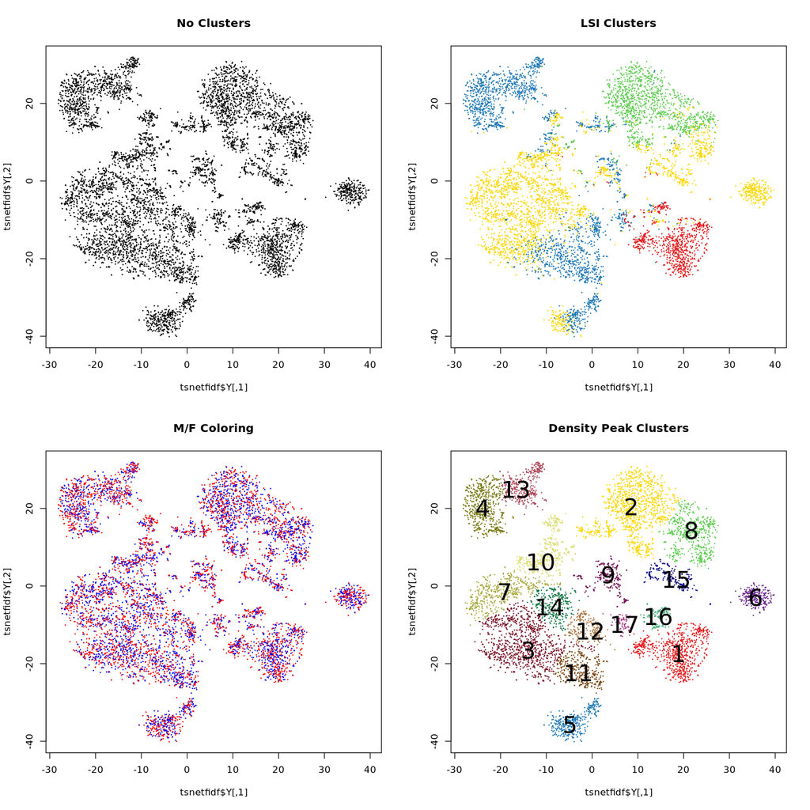

```r
sexcolors = read.table("6to8.xycalls.txt")
tsnecols = c("#E31A1C","#FFD700","#771122","#777711","#1F78B4","#68228B","#AAAA44",
 "#60CC52","#771155","#DDDD77","#774411","#AA7744","#AA4455","#117744",
 "#000080","#44AA77","#AA4488","#DDAA77")

options(repr.plot.width=12, repr.plot.height=12)
par(mfrow=c(2,2))

plot(tsnetfidf$Y,
     pch=20,
     main="No Clusters",
     cex=0.25)

plot(tsnetfidf$Y,
     pch=20,
     col=c("#1F78B4","#FFD700","#60CC52","#E31A1C")[as.factor(lsi_cells[match(colnames(tf_idf_counts),lsi_cells[,1]),2])],
     main="LSI Clusters",
     cex=0.25)

plot(tsnetfidf$Y,
     pch=20,
     col=c("blue","red")[sexcolors[match(colnames(tf_idf_counts),sexcolors[,1]),2]],
     main="M/F Coloring",
     cex=0.25)

plot(tsnetfidf$Y,
     pch=20,
     col=tsnecols[as.factor(dclust$clusters)],
     main="Density Peak Clusters",
     cex=0.25)

text(tsnetfidf$Y[dclust$peaks,1],
     tsnetfidf$Y[dclust$peaks,2],
     labels=dclust$clusters[dclust$peaks],
     cex=2.5)
```

```r
# 変数の削除
#rm(fly_summits_6to8)
rm(ncounts)
rm(ncounts.nosex)
rm(nfreqs)
#rm(tf_idf_counts)
rm(SVDtsne)
gc()
```

A matrix: 2 × 6 of type dbl

|  | used | (Mb) | gc trigger | (Mb) | max used | (Mb) |
| --- | --- | --- | --- | --- | --- | --- |
| Ncells | 1934125 | 103.3 | 14611447 | 780.4 | 15183115 | 810.9 |
| Vcells | 102654291 | 783.2 | 2244403789 | 17123.5 | 2805504141 | 21404.3 |

## Use case 3: Differential accessibility

- chromatin accessibility profilesに基づいて細胞のクラスターを定義した後、ゲノムのどの部位がクラスター間で異なるかを知りたいと思うかもしれません。
- それを把握するために、Monocleに実装されている線形モデリングフレームワークを使用します。
- このユースケースでは、中胚葉細胞のどの部位がタイムポイントで他のすべての細胞と相対的により開いているかを定義する手順を説明しますが、同じフレームワークを好きなように比較に適用することができます。

分析に入る前に、いくつかのハウスキーピングを行う必要があります。まず、差分アクセシビリティテストを実行するためにMonocleをロードします。これを行うには、レガシーバージョンの irlba を切り離してから Monocle をロードします。最後に、オープンしているサイトとクローズしているサイトを区別できるように、差分アクセシビリティテストからベータ値を報告するMonocleへの小さなパッチを作成しました。

注意: このコードは、コンピューティングクラスタ上の複数のプロセッサで実行するように実装されていますが、お好みのコンピューティング環境で動作させるには特別な修正が必要かもしれません。

```r
suppressPackageStartupMessages({
        detach("package:irlba", unload=TRUE)
        library(monocle)
})
```

```r
download.file(
        "http://krishna.gs.washington.edu/content/members/cusanovich/fly_embryogenesis/updated_data/vignette/monocle_patch.R",
        destfile = "monocle_patch.R")
source("monocle_patch.R")
```

```r
download.file(
     "http://krishna.gs.washington.edu/content/members/cusanovich/fly_embryogenesis/updated_data/vignette/6to8.read.report.txt",
     destfile = "6to8.read.report.txt")
readcounts = read.table("6to8.read.report.txt", header=T)
```

summit matrixにはたくさんの細胞のデータが含まれているので、まず生殖層と予測されている細胞のサブセットを抽出する。 次に、少なくとも50個の細胞で観察されなかった部位をフィルタリングする。

```r
goodcells = match(lsi_cells[,1], colnames(fly_summits_6to8))
da_mat = fly_summits_6to8[,goodcells]
num_cells_ncounted = rowSums(da_mat)
da_mat_final = da_mat[num_cells_ncounted >= 50,]

rm(da_mat)
gc()
```

A matrix: 2 × 6 of type dbl

|  | used | (Mb) | gc trigger | (Mb) | max used | (Mb) |
| --- | --- | --- | --- | --- | --- | --- |
| Ncells | 2619429 | 139.9 | 11689158 | 624.3 | 15183115 | 810.9 |
| Vcells | 146908478 | 1120.9 | 1795523032 | 13698.8 | 2805504141 | 21404.3 |

次に、サイト x 細胞マトリックスを`Cell Data Set ('CDS')`にロードしたいと思います。最初のステップは、"表現型 "データフレームをセットアップすることです。これは、個々の細胞に関するあらゆる種類の情報を保存するためのフレームワークです。

```r
readcounts.assigned = readcounts[match(lsi_cells[,1],rownames(readcounts)),]
clusterfactor = factor((lsi_cells[,2] == '4')+0,levels=c("0","1"))
pda = data.frame(as.character(lsi_cells[,1]),as.numeric(log10(readcounts.assigned[,2])),clusterfactor)
names(pda) = c("CellID", "ReadDepth","CellCluster")
pda = new("AnnotatedDataFrame", data = pda)
```

次に、データのfeature（この場合はサイト）を保存するためのフレームワークである `feature` データフレームを設定します。

```r
fda = as.data.frame(as.character(rownames(da_mat_final)))
names(fda) = "Peak"
fda = new("AnnotatedDataFrame", data = fda)
```

そして、`feature`データフレームと`phenotype`データフレームを、サイト x 細胞マトリックスと組み合わせてCDSにする。 データはbinary matrixなので、`expressionFamily`をbinomialffに設定することで達成できる。

```r
rownames(da_mat_final) = NULL
colnames(da_mat_final) = NULL
submat_cds = newCellDataSet(da_mat_final,
                 featureData = fda,
                 phenoData = pda,
                 expressionFamily = binomialff(),
                 lowerDetectionLimit = 1)

pData(submat_cds)$Size_Factor = 1
```

```r
# Here we just delete some variables that we won’t need anymore to free up RAM.
rm(readcounts.assigned)
rm(fda)
rm(pda)
rm(da_mat_final)
gc()
```

A matrix: 2 × 6 of type dbl

|  | used | (Mb) | gc trigger | (Mb) | max used | (Mb) |
| --- | --- | --- | --- | --- | --- | --- |
| Ncells | 2683971 | 143.4 | 9351327 | 499.5 | 15183115 | 810.9 |
| Vcells | 147062954 | 1122.1 | 1436418426 | 10959.1 | 2805504141 | 21404.3 |

これで、differentially accessible sitesを特定するための尤度比検定を実行する準備が整いました。 Monocle には `differentialGeneTest` 関数を使った便利なラッパーが用意されています。このステップは数分で実行できます。

```r
differtest = differentialGeneTest(submat_cds,
                                  fullModelFormulaStr = "~CellCluster + ReadDepth",
                                  reducedModelFormulaStr = "~ReadDepth",
                                  cores = 32)
head(differtest[order(differtest$qval),])
```

A data.frame: 6 × 6

|  | status <chr> | family <chr> | pval <dbl> | beta <dbl> | qval <dbl> | Peak <chr> |
| --- | --- | --- | --- | --- | --- | --- |
| 5601 | OK | binomialff | 1.228447e-225 | 3.504141 | 6.403772e-221 | chr2L_12347817_12348170 |
| 40930 | OK | binomialff | 4.578410e-212 | 2.951469 | 1.193340e-207 | chr3R_24393584_24394099 |
| 23613 | OK | binomialff | 1.088239e-171 | 2.822114 | 1.890960e-167 | chr3L_8692868_8693230 |
| 35884 | OK | binomialff | 8.353864e-160 | 2.860700 | 1.088696e-155 | chr3R_11837781_11838011 |
| 13128 | OK | binomialff | 4.025508e-159 | 2.467322 | 4.196914e-155 | chr2R_7896266_7896786 |
| 37379 | OK | binomialff | 2.395295e-157 | 2.870382 | 2.081072e-153 | chr3R_15075624_15076046 |

- このtestでは、筋原性中胚葉細胞 (myogenic mesoderm cells)は19,535個の部位が胚中の他のすべての細胞と比較して有意に異なるaccessibility（1% FDR）を持つことがわかりました。
- そのうち8,398個の部位が他の細胞よりも筋原性中胚葉ではアクセスしやすく、11,137個の部位は筋原性中胚葉ではアクセスしにくくなっています。
- リストのトップにあるサイトは、あなたが期待するものと一致していることがわかります。
  - 例えば、2番目に重要なヒットは、「[融合適合型筋芽細胞 (fusion-competent myoblasts)](http://www.sdbonline.org/sites/fly/gene/lamedk1.htm)」の master regulator として知られているlmdのプロモーターでした。

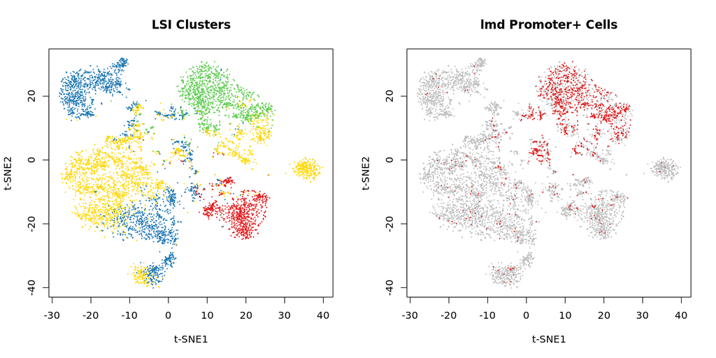

```r
options(repr.plot.width=12, repr.plot.height=6)
par(mfrow=c(1,2))

plot(tsnetfidf$Y,pch = 20,
     col = c("#1F78B4", "#FFD700", "#60CC52", "#E31A1C")[as.factor(lsi_cells[match(colnames(tf_idf_counts),
     lsi_cells[,1]),2])],
     main = "LSI Clusters",
     cex = 0.25,
     xlab = "t-SNE1",
     ylab = "t-SNE2")
plot(tsnetfidf$Y[match(pData(submat_cds)$CellID,colnames(tf_idf_counts)),][order(exprs(submat_cds)[38943,]),],
     pch = 20,
     main = "lmd Promoter+ Cells",
     cex = 0.25,
     col = ifelse(exprs(submat_cds)[38943,][order(exprs(submat_cds)[38943,])] > 0,"#E31A1C","gray"),
     xlab = "t-SNE1",
     ylab = "t-SNE2")
```

```r
rm(da_mat_final)
rm(submat_cds)
gc()
```

A matrix: 2 × 6 of type dbl

|  | used | (Mb) | gc trigger | (Mb) | max used | (Mb) |
| --- | --- | --- | --- | --- | --- | --- |
| Ncells | 2801078 | 149.6 | 9351327 | 499.5 | 15183115 | 810.9 |
| Vcells | 104269442 | 795.6 | 919307793 | 7013.8 | 2805504141 | 21404.3 |

## Use case 4: Order cells in development

シングルセル解析の非常に強力な側面の一つは、細胞の発生の軌跡を追跡できることである。Cusanovichらの論文では、scATAC-seqデータを用いて発生の軌跡を特定できることが示されています。ここでは、その解析の基本的なステップを説明します。

- この解析では2-4時間のタイムポイントに着目し、そのタイムポイントの細胞を`cds`にロードします。
- これらの細胞のt-SNE分析に基づいて、我々は次の7つの細胞タイプに細胞を分類することができました：
  - ‘Unknown’, ‘Collisions’, ‘Blastoderm’, ‘Neural’, ‘Ectoderm’, ‘Mesoderm’, ‘Endoderm’.
- しかし、私たちが本当に見たかったのは、細胞が胚盤胚葉状態 (blastoderm state) から胚葉層へとどのように移行していくのかということでしたので、Monocleを使って細胞を進行方向に並べて、ゲノムの制御ランドスケープが発生を通してどのように変化していくのかについて調べました。

注意：この解析では疎なデータを改善するため、個々のwindowのリード数をそのまま使用する代わりに、互いの近傍にあるすべての部位をマージしました。

```r
# 必要なデータのダウンロード
download.file(
    "http://krishna.gs.washington.edu/content/members/cusanovich/fly_embryogenesis/updated_data/vignette/2to4_files.tar.gz",
    destfile = "2to4_files.tar.gz")
system("tar -xzf 2to4_files.tar.gz && rm 2to4_files.tar.gz")
```

```r
cds_2to4 = readRDS("./2to4_files/cds_2to4_aggregated.rds")
overlapped_sites = read.table('./2to4_files/2to4.overlapped_sites.bed')
cell_classification = read.table('./2to4_files/2to4.germlayers.txt')
table(cell_classification$V2)
```

```
Blastoderm Collisions   Ectoderm   Endoderm   Mesoderm     Neural    Unknown
      2662        164       1865        575       1496        103        358
```

この時点で見つかった各細胞タイプのDAサイトの上位100サイトを収集する（‘Unknown’, ‘Collisions’カテゴリのサイトを除く）。 サイトを収集した後、overlap しているサイトを決定する必要があります。

```r
DA_monocle_list = lapply(seq(1,7,1), FUN = function(x) {
        DA_file_name = paste0('./2to4_files/2to4.sigopen.cluster', x, '.txt')
        DA_file = read.csv(DA_file_name, sep = '\t', header = F)
        DA_file$GL = x
        return (DA_file)
})

DA_monocle = data.table::rbindlist(DA_monocle_list)
colnames(DA_monocle) = c('chr','start', 'end', 'qvalue', 'GL')
DA_monocle$coord = paste(DA_monocle$chr, DA_monocle$start, DA_monocle$end, sep = '_')

get_top_DA = function(cluster = 1, DA_results=DA_GL, num = 500){
        DA_this_cluster = subset(DA_results, GL == cluster)
        DA_this_cluster = DA_this_cluster[order(DA_this_cluster[,qvalue]),]
        if (num > nrow(DA_this_cluster)){
            return (DA_this_cluster[c(1:nrow(DA_this_cluster)),]$coord)
        } else {return (DA_this_cluster[c(1:num),]$coord)}
}

DA_sites_to_order = unlist(lapply(c(1,3,4,5,6), get_top_DA, DA_results = DA_monocle,num=100))
overlapped_DA_sites_to_order = subset(overlapped_sites, V4 %in% DA_sites_to_order)$V8
```

その後、2-4時間のCDSを更新して、生殖層の割当が何であるかを追跡し、どのサイトを細胞の順序付けに使用すべきかを確立します（私たちが上で定義したトップDAサイト）。

```r
rownames(cell_classification) = cell_classification$V1
germ_layer_pallet = c('Unknown'='#68228B', 'Blastoderm'='#808080', 'Neural'='#1F78B4', 'Ectoderm'='#FFD700',
                      'Mesoderm'= '#E31A1C', 'Endoderm'='#60CC52', 'Collisions'='saddlebrown')
cell_classification = cell_classification[rownames(pData(cds_2to4)),]
cds_2to4$germ_layer_name = cell_classification$V2
fData(cds_2to4)$use_for_ordering = FALSE
cds_2to4 = setOrderingFilter(cds_2to4, overlapped_DA_sites_to_order)
```

CDSをセットアップしたら、次は`DDRTree`を使って発生の軌跡を学習し、その軌跡上に`orderCells`関数を使って細胞を配置します。

```r
cds_2to4 = reduceDimension(cds_2to4,reduction_method="DDRTree",
                                    ncenter=200,
                                    max_components = 3,
                                    maxIter=1000,
                                    auto_param_selection = FALSE,
                                    residualModelFormulaStr="~as.numeric(num_genes_expressed)",
                                    )
```

```r
options(warn=-1)
cds_2to4 = orderCells(cds_2to4)
```

```r
#This is just a convenience function for plotting to figures side-by-side, since ggplot2 can't do that by default.
#from http://www.cookbook-r.com/Graphs/Multiple_graphs_on_one_page_(ggplot2)/
multiplot <- function(..., plotlist=NULL, file, cols=1, layout=NULL) {
  library(grid)
  plots <- c(list(...), plotlist)
  numPlots = length(plots)
  if (is.null(layout)) {
   layout <- matrix(seq(1, cols * ceiling(numPlots/cols)),
                    ncol = cols, nrow = ceiling(numPlots/cols))
  }
  if (numPlots==1) {print(plots[[1]])}
  else {
        grid.newpage()
        pushViewport(viewport(layout = grid.layout(nrow(layout), ncol(layout))))
        for (i in 1:numPlots) {
          matchidx <- as.data.frame(which(layout == i, arr.ind = TRUE))

          print(plots[[i]], vp = viewport(layout.pos.row = matchidx$row,
                                          layout.pos.col = matchidx$col))
        }
      }
    }
```

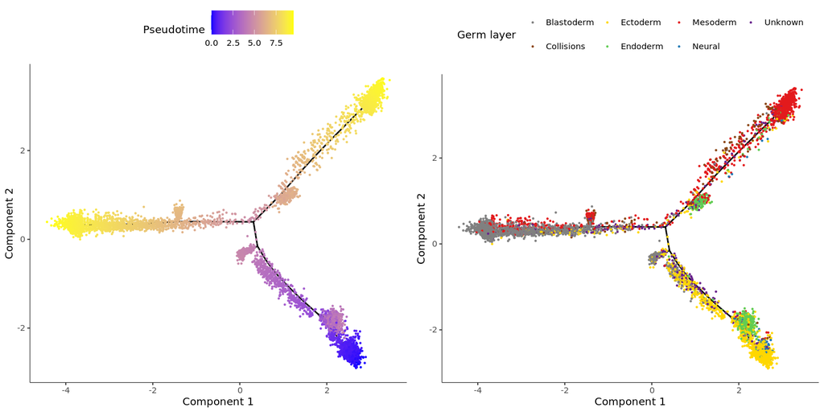

```r
options(repr.plot.width=12, repr.plot.height=6)
p1 = plot_cell_trajectory(cds_2to4, 1, 2, color_by = 'Pseudotime', show_branch_points = F, cell_size = 0.5) +
     scale_colour_gradient2(name = 'Pseudotime', mid='blue', high = 'yellow')
p2 = plot_cell_trajectory(cds_2to4, 1,2, color_by = 'germ_layer_name', show_branch_points = F, cell_size = 0.5) +
     scale_color_manual(values = germ_layer_pallet) + labs (color = 'Germ layer')
multiplot(p1, p2, cols=2)
```

- Monocleでできる分析の例については、[monocleのウェブサイト](http://cole-trapnell-lab.github.io/monocle-release/docs_mobile/)をご覧ください。
- 処理されたデータを使って、我々が特定した細胞のクラスタのブラウザトラックをチェックしたい方は、我々の[コンパニオンサイト](http://shiny.furlonglab.embl.de/scATACseqBrowser/)をご覧ください。